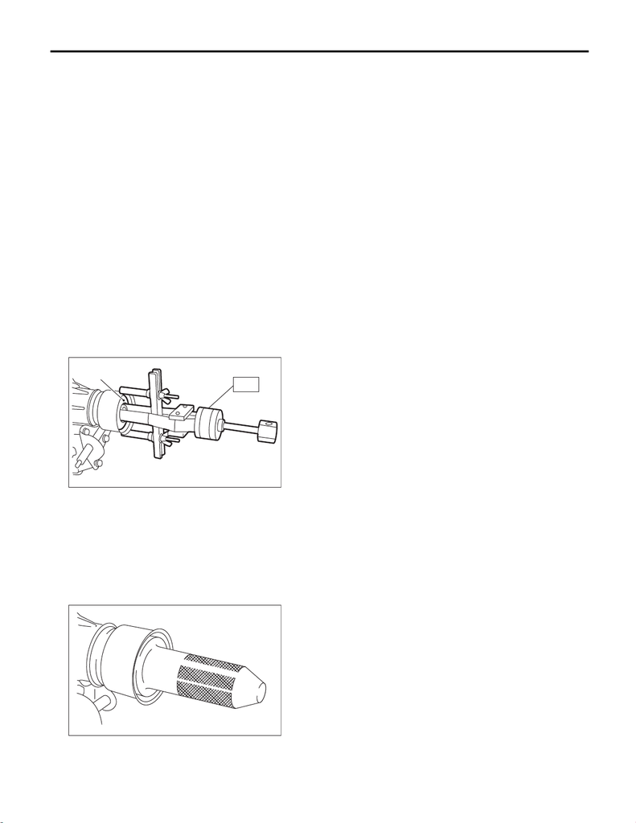

6MT(TY85)-27

Oil Seal

MANUAL TRANSMISSION AND DIFFERENTIAL

3. Oil Seal

A: INSPECTION

Check that there is no oil leaking from the oil seal.

If there is any deformation, hardening, wear or oth-

er malfunctions of the oil seal, perform the follow-

ing:

• Replace the oil seal.

• Inspect the propeller shaft.

B: REPLACEMENT

1) Clean the transmission exterior.

2) Drain transmission gear oil completely. <Ref. to

6MT(TY85)-26, REPLACEMENT, Transmission

Gear Oil.>

3) Remove the rear exhaust pipe and muffler.

<Ref. to EX(STI)-12, REMOVAL, Rear Exhaust

Pipe.> <Ref. to EX(STI)-14, REMOVAL, Muffler.>

4) Remove the heat shield cover.

5) Remove the propeller shaft. <Ref. to DS-12, RE-

MOVAL, Propeller Shaft.>

6) Using the ST, remove the oil seal.

ST 398527700 PULLER ASSY

7) Using the ST, install the oil seal.

NOTE:

• When grease is not applied to the oil seal lips,

apply the transmission gear oil to the oil seal lips.

• Use a new oil seal.

ST 498057300 INSTALLER

8) Install the propeller shaft. <Ref. to DS-14, IN-

STALLATION, Propeller Shaft.>

9) Install the heat shield cover.

Tightening torque:

18 N·m (1.8 kgf-m, 13.3 ft-lb)

10) Install the rear exhaust pipe and muffler. <Ref.

to EX(STI)-12, INSTALLATION, Rear Exhaust

Pipe.> <Ref. to EX(STI)-15, INSTALLATION, Muf-

fler.>

11) Pour in transmission gear oil and check the oil

level. <Ref. to 6MT(TY85)-26, REPLACEMENT,

Transmission Gear Oil.>

(A) Oil seal

MT-00451

(A)

ST

MT-00099